# SQUIBS Update Example

Week of 12/3/2023 - Week of 12/10/2023

## Cumulative results

**Cumulative Sample Summary**

Number of weeks sampled: **33**

Number of samples received: **65**

Number of samples processed: **65**

Number of individual squid processed to date: **8077**

**News/comments:**

- A SQUIBS sampling demonstration was given to students from the Knauss Fellowship program on 12/8.
- At least 2 samples expected for Week of 12/17, one from area 6A and one from 6B.
- One hermaphroditic organism was found in a sample from 5Zw during week 40 (Week of Oct 1). It was found to have a fully-developed testis, spermatophores, and accessory glands, but no nidamental gland or ovary. Its parameter values were recorded but have been excluded from the generation of the cumulative data figures. The organism is currently preserved in the freezer at the Narragansett Lab.

### Lengths and Weights

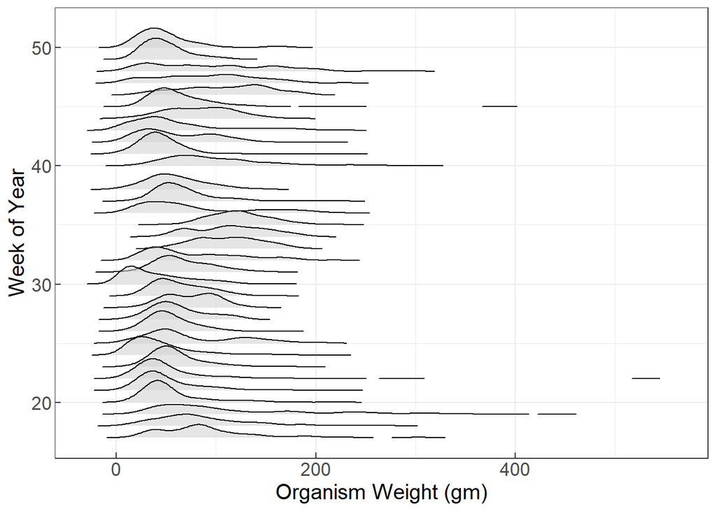

**Figure 1.** Organism weight frequency distributions over time for longfin squid samples collected in 2023.

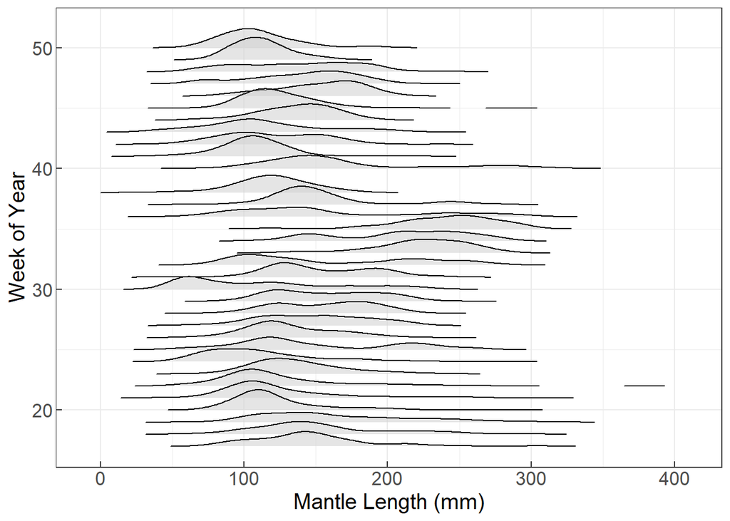

**Figure 2.** Organism length frequency distributions over time for longfin squid samples collected in 2023.

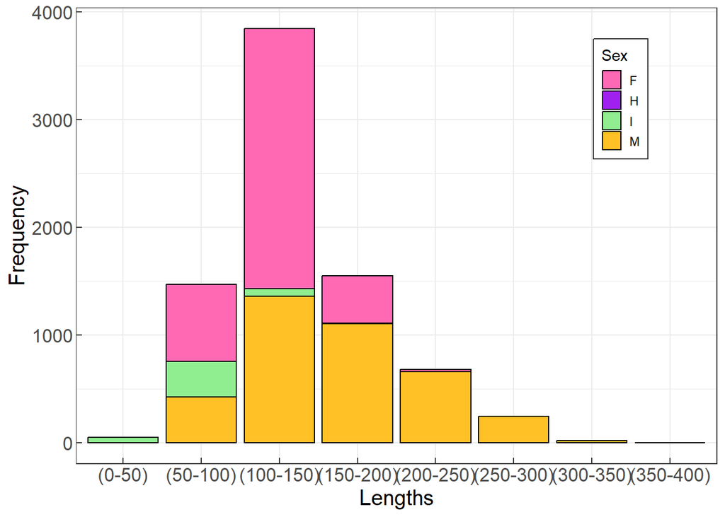

### Sex and Maturity

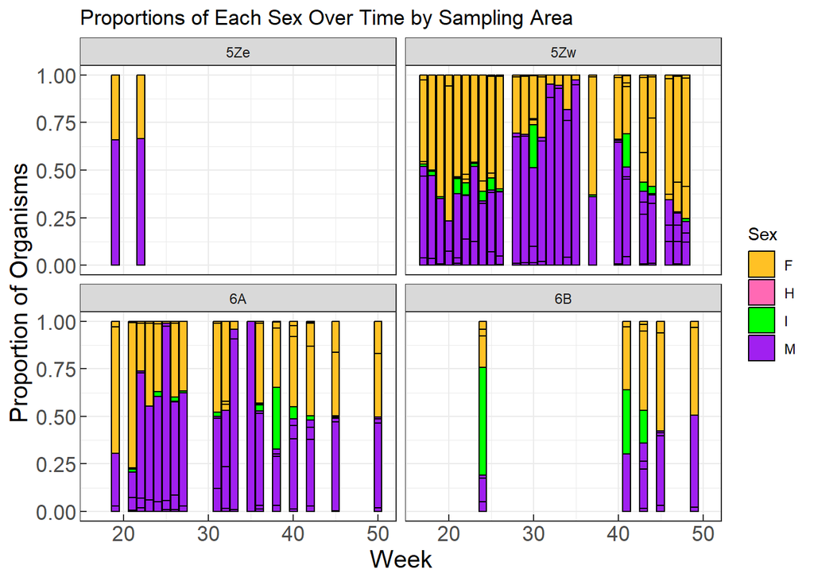

**Figure 4.** Proportions of each sex over time across sampling areas.

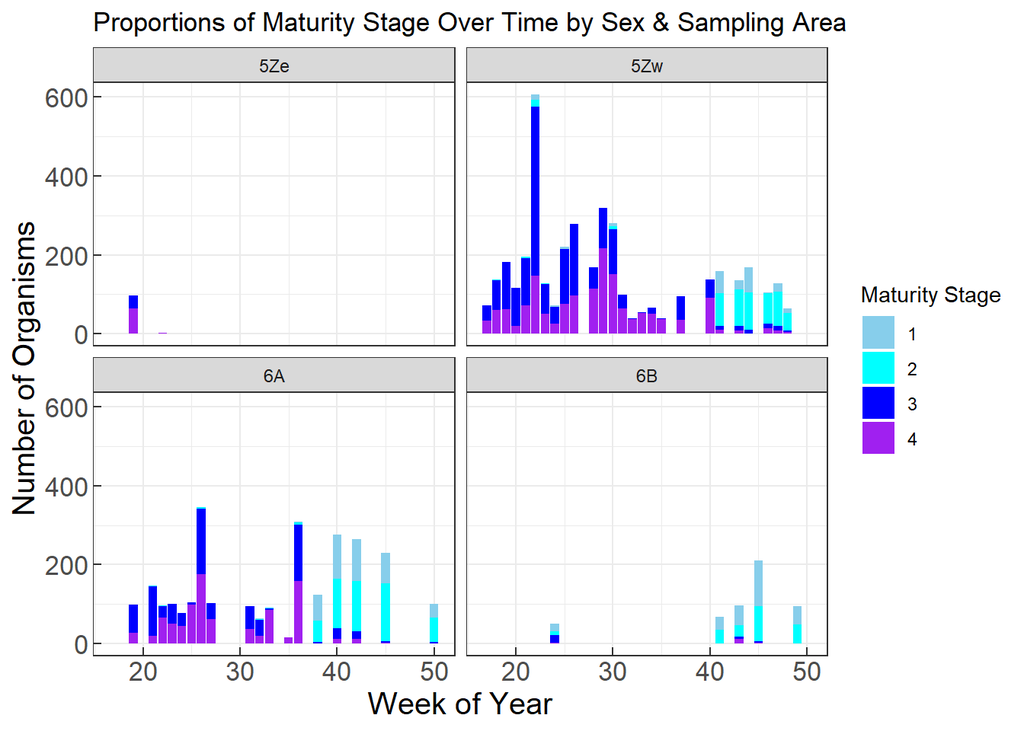

## Biweekly results

### Sex and Maturity

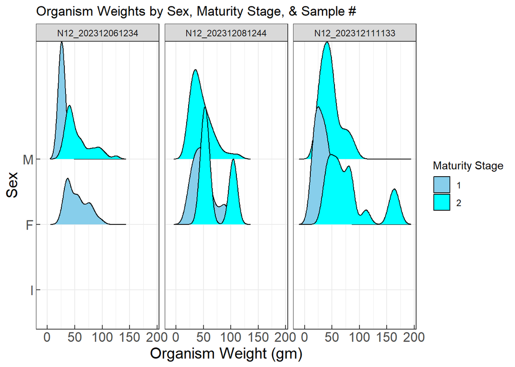

**Figure 6.** Organism weight frequency distributions of processed samples by sex (I = indeterminate, F= female, M = male) and maturity stage (1 = immature, 2 = advanced immature, 3 = nearly mature, 4 = mature).

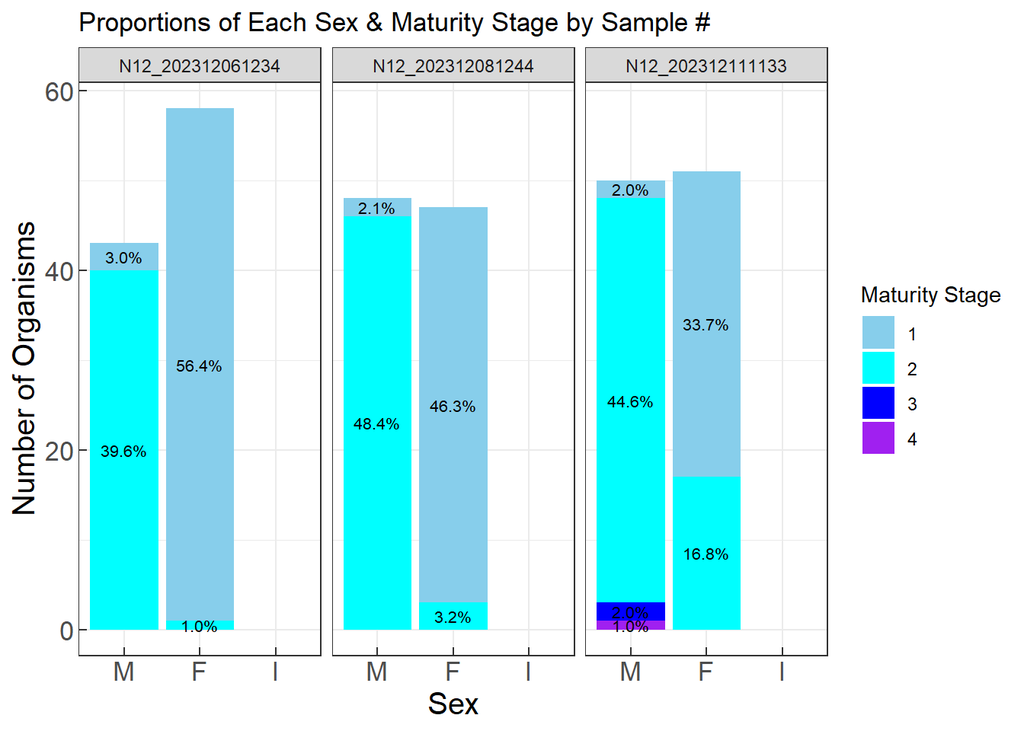

**Figure 7.** Total number of squid by sex and percent composition of maturity stages for each sample processed for current 2 week period.

## Map

Reference map of potential collection locations. This project uses [NAFO Regulatory Areas](https://www.nafo.int/Fisheries/Fishing-Activity-in-the-NRA) as a point of reference from which to target fishing trips, in an effort to collect squid samples throughout a representative spatial range of the fishery.

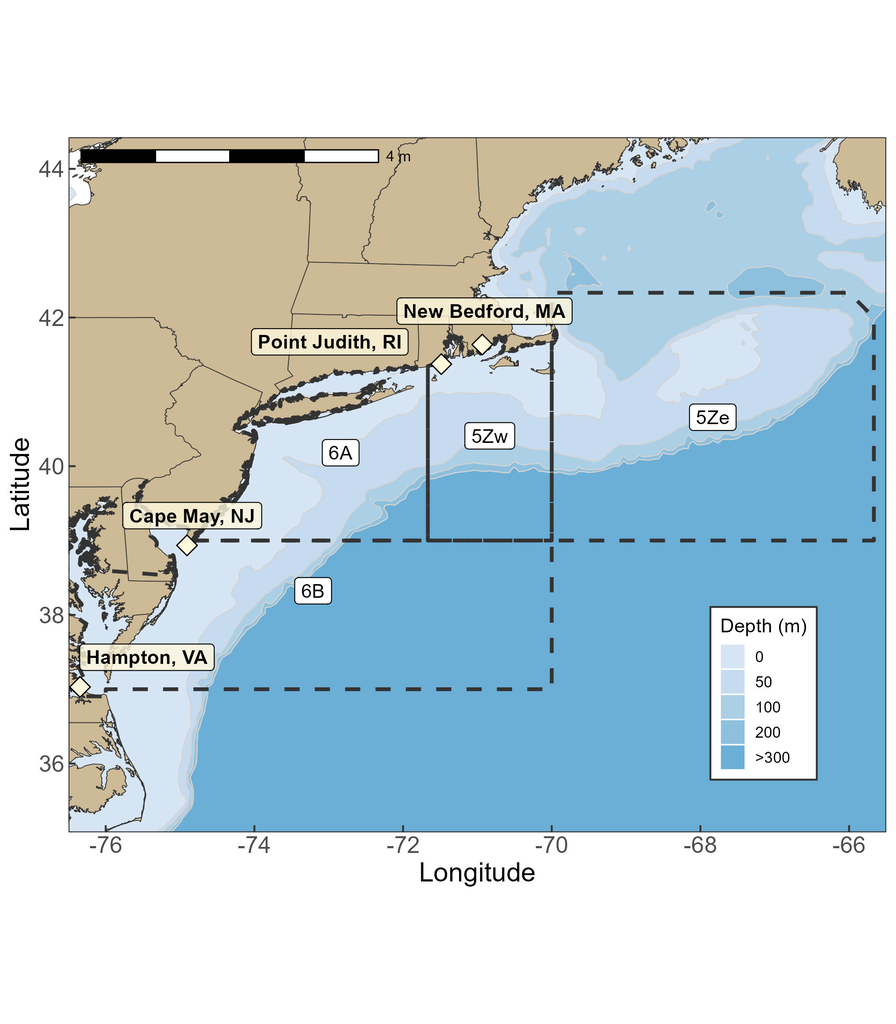